# Sample size analysis example

This example comes directly from [Maslen et al. 2023](https://doi.org/10.1111/2041-210X.14094), for more details behind the methodology go to this paper. If you use this package for sample size analysis in an associated paper or otherwise, please cite [Maslen et al. 2023](https://doi.org/10.1111/2041-210X.14094).

## Crayweed restoration project

Researchers within the Operation Crayweed Restoration Project in Sydney are restoring the locally extinct macro-algae *Phyllospora comosa* (“crayweed”: see [Coleman et al., 2008](https://doi.org/10.1111/j.1529-8817.2008.00541.x); [Campbell et al., 2014](https://journals.plos.org/plosone/article?id=10.1371/journal.pone.0084106); [Vergés et al., 2020](https://doi.org/10.1111/emr.12413) and are interested in the effect of this restoration on associated ecological communities ([Marzinelli et al., 2014](https://link.springer.com/article/10.1007/s10811-013-0158-5), [2016](https://doi.org/10.1111/rec.12292); [Wood et al., 2019](https://www.publish.csiro.au/mf/MF18226)). Pilot data have already been collected, where the abundance of fish species in nine open ocean sites have been recorded in 2015. We are interested in observing if there is a change in mean fish abundance between control sites (those in Sydney without crayweed) and restored sites (similar sites where crayweed has recently been transplanted). There are plans to collect more data in the future, however there is an upper bound of approximately 24 possible spatially independent restored or control coastal bays/sites within the Sydney region and surroundings.

In this example we attempt to answer the following experimental design questions:

1. How many sites are required to likely detect $20\%$ differences between treatments?
2. Under the maximum independent sampling design of 24 sites, what are the size of effects that are likely to be detected?

### Load packages:

Ecopower can be installed from CRAN using `install.packages("ecopower")`, however for the latest version users can install from GitHub with `devtools::install_github("BenMaslen/ecopower")`.

```r
#to install latest version of ecopower on github:
#devtools::install_github("BenMaslen/ecopower")

#load libraries
library(ecopower)
library(mvabund)
library(ecoCopula)
library(ggplot2)
library(RColorBrewer)
```

### Read in data:

The first 34 columns of the `fish` data set make up the multivariate abundance matrix of fish counts across our 9 sites.

```r
#read in data
data("fish")

#create mvabund abundance matrix
fish_data <- fish
abund <- mvabund(fish_data[, 1:34])

#set Site.Type as a factor
fish_data$Site.Type <- factor(fish_data$Site.Type, levels = c("control", "restored", "reference"))
```

### Fit a model to the data:

Below we first fit a `manyglm` model, and then a copula model using the `cord` function from the `ecoCopula` package to our pilot data as our data generating model.

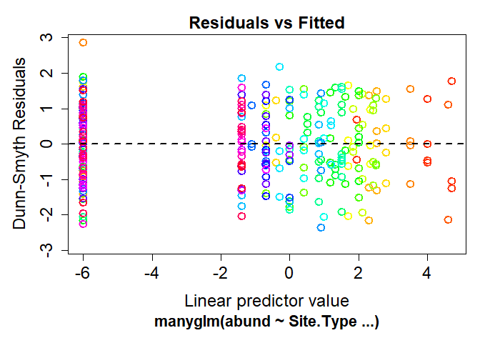

```r
#fit the model
fit       <- manyglm(abund ~ Site.Type, family = "negative.binomial", data = fish_data)
fit.cord  <- cord(fit)

#check model assumptions
plot(fit)
```

### Specify effect of interest:

To specify an effect of interest, we first specify a list of responses (or taxa) we believe are ‘increasing’ or ‘decreasing’ in response to our treatment. Responses/taxa we do not specify as either ‘increasers’ or ‘decreasers’ are assumed to have no effect.

Next we specify the multiplicative effect size and term of interest in the effect_alt function. Here `effect_size=1.2` is a $20\%$ change in mean abundance.

```r
#specify 'increaser' and 'decreaser' species:
increasers <- c("Aplodactylus.lophodon", "Atypichthys.strigatus", "Cheilodactylus.fuscus",
                "Olisthops.cyanomelas", "Pictilabrius.laticlavius")
decreasers <- c("Abudefduf.sp", "Acanthurus.nigrofuscus", "Chromis.hypsilepis",
                "Naso.unicornis", "Parma.microlepis", "Parupeneus.signatus",
                "Pempheris.compressa", "Scorpis.lineolatus", "Trachinops.taeniatus")

#specify effect size of interest
coeff.alt <- effect_alt(fit, effect_size = 1.2, increasers, decreasers, term = "Site.Type")
```

Notice in the original pilot data we have three treatments but are only interested in comparing control vs. restored sites. In order to simulate under only control and restored sites, we can create a new dataset where reference sites have been relabeled as restored (below - `fish_data_sim`) and simulate under this design using the `newdata` argument in `powersim()`.

Note that we could have just started out fitting a model to only restored and control sites, however we would lose samples that could be used to help estimate nuisance parameters like overdispersion and covariance. Thus we are effectively ‘borrowing strength’ from the reference sites to help in the estimation of our nuisance parameters.

```r
fish_data_sim            <- fish_data
fish_data_sim$Site.Type[fish_data_sim$Site.Type=="reference"] <- "restored"
fish_data_sim$Site.Type  <- factor(fish_data_sim$Site.Type)
```

### Undergo single power simulation:

Let’s start by estimating power for a single sample size specification.

Below we calculate power for a sample size of $N=100$ using our pre-specified effect size (`coeff.alt`) of $20\%$ differences in mean abundance.

Note that `nsim` and `ncrit` have been set to 50 and 49 respectively in order to run timely, however in practice you would want to set these to larger values (we recommend setting `nsim=1000` and `ncrit=4999`) to get a more accurate estimate of power.

```r
powersim(fit.cord, N=100, coeff.alt, term="Site.Type", nsim=50, ncrit=49, newdata = fish_data_sim, ncores=2)
```

```
#> Time elapsed: 0 hr 0 min 20 sec
#> Power: 0.48
```

Based on this initial power simulation we would need more samples in order to obtain the conventional power target of $80\%$.

## Produce a single power curve:

In order to answer our first experimental design question, we can estimate power across a range of sample sizes for an effect size of $20\%$ differences in mean abundance. By plotting the results, we can observe the sample size required to reliably detect (with a conventional power target of $80\%$) the effect of interest.

Users could also plot multiple power curves to get an idea of the variability in the power estimates (as in [Maslen et al. 2023](https://doi.org/10.1111/2041-210X.14094)).

Note: The below code takes ~10minutes-1hour to run depending on the speed of your computer and the number of logical processors you have. As such, this code has not been evaluated by default. Instead, the resultant figure has been added for reference. If you want to run this code and reduce computation time, you can reduce `nsim` or `ncrit`, however this will also make power estimates more variable.

First we estimate power at each sample size of interest:

```r
#specify sample sizes to simulate under
sample_sizes    <- c(10, 25, 50, 75, 100, 125, 150, 175, 200, 225, 250, 275, 300)
power_estimates <- rep(NA, length(sample_sizes))

#loop through sample sizes and estimate power at each step
for (i in 1:length(sample_sizes)){
  power_estimates[i] <- powersim(fit.cord, N = sample_sizes[i], coeff.alt, term = "Site.Type",
                                 nsim = 1000, ncrit = 4999, newdata = fish_data_sim)
}
```

Next, let’s save the results as a data frame and produce a plot against the conventional power target of $80\%$:

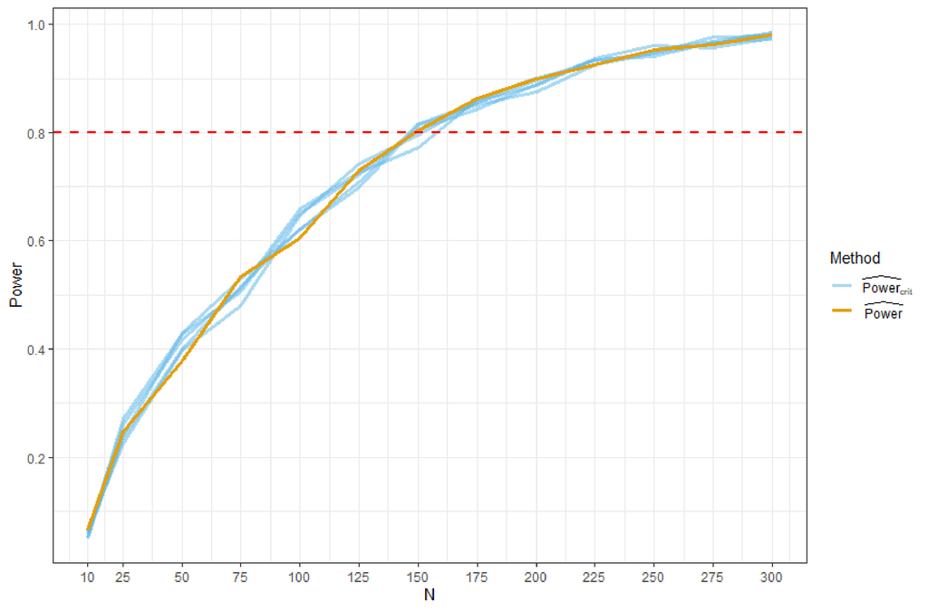

```r
#store the results in a data.frame
powercurve_dat <-  data.frame(sample_sizes = sample_sizes, Power = unlist(power_estimates))

#plot power curves
ggplot(powercurve_dat, aes(x = sample_sizes, y = Power)) +
  geom_line(size = 1.06) + theme_bw() + geom_hline(yintercept = 0.8, linetype = "dashed", color = "red", size=1) +
  xlab("N") + ylab("Power") + scale_x_continuous(breaks = sample_sizes) +
  scale_y_continuous(breaks = c(0.2, 0.4, 0.6, 0.8, 1.0))
```

This suggests that we require a sample size of at-least $N \approx 150$ in order to likely detect $20\%$ changes in mean abundances, using a conventional power target of $80\%$.

Thus we have answered our first experimental design question!

## Multiple effect size power curve:

As we are simulating from copula models with small sample sizes, we will also increase `n.samp` (number of simulations for importance sampling in copula modelling) and decrease `nlv` to 1 (number of latent factors in the copula) as recommended in the `cord` function description.

Note: The below code takes ~30minutes-2hours to run depending on the speed of your computer and the number of logical processors you have. As such, this code has not been evaluated by default. Instead, the resultant figure has been added for reference. If you want to run this code and reduce computation time, you can reduce `nsim` or `ncrit`, however this will also make power estimates more variable.

First we estimate power at each sample size and effect size of interest:

```r
#specify effect sizes and sample sizes to loop through
sample_sizes <- c(3:12)*2
effect_sizes <- c(1.1, 1.2, 1.3, 1.4, 1.5, 1.6, 1.7, 1.8, 1.9, 2)
mult_power_estimates <- rep(NA,length(sample_sizes)*length(effect_sizes))

#loop through sample sizes and effect sizes
for (j in 1:length(effect_sizes)){
  coeff.alt <- effect_alt(fit, effect_size = effect_sizes[j], increasers, decreasers, term = "Site.Type")
  for (i in 1:length(sample_sizes)){
    try(mult_power_estimates[10*(j-1)+i] <- powersim(fit.cord, N = sample_sizes[i], coeff.alt, term = "Site.Type", nsim = 1000,
                                                     ncrit = 4999, newdata = fish_data_sim, nlv = 1, n.samp = 500))
  }
}
```

Next, let’s save the results as a data frame and produce a plot of the resulting power estimates:

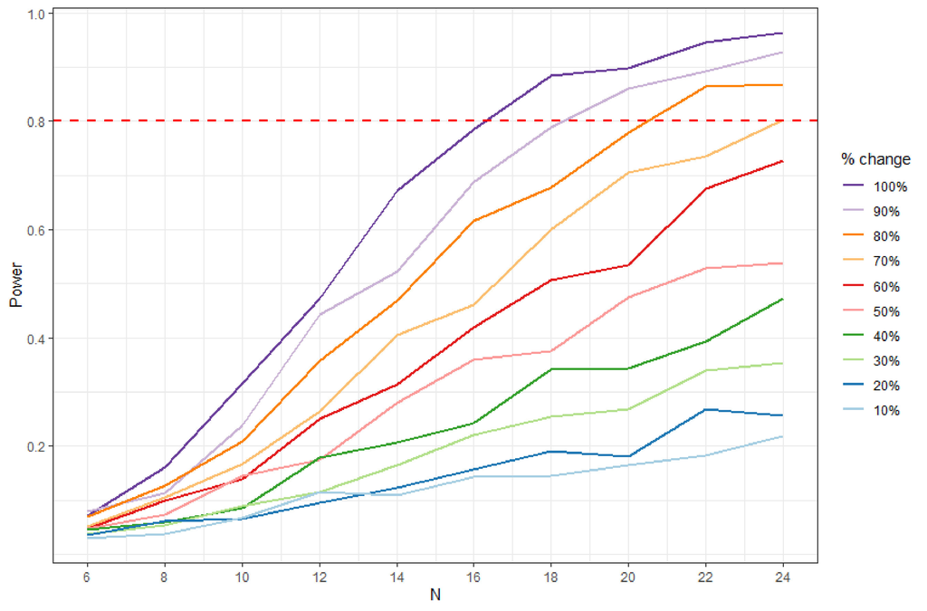

```r
#store the results in a data.frame
mult_powercurve_dat <- data.frame(sample_sizes = rep(sample_sizes, times = length(effect_sizes)),
                                  power_estimates = unlist(mult_power_estimates),
                                  Perc_Change = factor(rep(c("10%", "20%", "30%", "40%", "50%", "60%",
                                                             "70%", "80%", "90%", "100%"), each = 10),
                                                     levels = c("100%", "90%", "80%", "70%", "60%", "50%",
                                                              "40%", "30%", "20%", "10%")),
                                  effect_sizes = rep(effect_sizes, each = length(sample_sizes)))



#plot multiple power curve
ggplot(mult_powercurve_dat, aes(x = sample_sizes, y = power_estimates, colour = Perc_Change)) +
  geom_line(linewidth = 1.05) + theme_bw() + geom_hline(yintercept = 0.8, linetype = "dashed", color = "red", size = 1) +
  xlab("N") + ylab("Power") + scale_x_continuous(breaks = sample_sizes) +
  scale_y_continuous(breaks = c(0.2, 0.4, 0.6, 0.8, 1.0)) + scale_color_brewer(palette = "Paired", direction = -1, name = "% change")
```

In the above plot we can observe that under the maximum balanced sample size of $N=24$ sites, the smallest effect size to be observed under a conventional power target of $80\%$ is effect_size$\approx 1.7$, or equivalently $70 \%$ changes in the mean abundances of fish species. The pilot survey included $N_{\text{pilot}}=9$ sites, which would not be able to reliably detect any of the simulated effect sizes.

Thus we have answered our second experimental design question!

Note that we could also have just produced a single power curve here for a sample size of $N=24$ across our effect sizes of interest, which would also have saved a lot of time (and still answered our second experimental design question). The multiple effect size plot that we produced however will also give us insight into the size of effects we can detect across the entire range of balanced sample sizes.

## Sensitivity analysis:

As mentioned in [Maslen et al. 2023](https://doi.org/10.1111/2041-210X.14094) it is also a good idea to check how sensitive our prior assumptions are in generating our effect size of interest and estimating power.

Let’s produce some power curves where we play around with the most abundant species and alter the overdispersion parameter, to see how sensitive our power estimates are based on these parameters.

First let’s create a new cord object and halve the overdispersion by doubling overdispersion parameter theta.

```r
#new cord model
fit.cord_doub_theta <- cord(fit)

#change theta to be doubled
fit.cord_doub_theta$obj$theta <- fit.cord$obj$theta*2
```

Secondly, let’s try investigate what happens when we change the most abundant species *Atypichthys.strigatus* from an ‘increaser’ to a ‘no effect’ taxa, by removing it from the ‘increaser’ species list.

```r
increasers_no_abund <- c("Aplodactylus.lophodon", "Cheilodactylus.fuscus",
                         "Olisthops.cyanomelas", "Pictilabrius.laticlavius" )
```

Now, let’s re specify the effect size of interest as $20\%$ changes in mean abundance via setting effect_size$=1.2$. We will also specify another coefficient matrix without the most abundant species in it.

```r
coeff.alt_no_abund  <- effect_alt(fit, effect_size = 1.2, increasers_no_abund, decreasers, term = "Site.Type")
coeff.alt           <- effect_alt(fit, effect_size = 1.2, increasers, decreasers, term = "Site.Type")
```

Now we can estimate power with these changes.

Note: The below code takes ~20minutes-2hours to run depending on the speed of your computer and the number of logical processors you have. As such, this code has not been evaluated by default. Instead, the resultant figure has been added for reference. If you want to run this code and reduce computation time, you can reduce `nsim` or `ncrit`, however this will also make power estimates more variable.

```r
sample_sizes <- c(10, 25, 50, 75, 100, 125, 150, 175, 200, 225, 250, 275, 300)
power_estimatesa <- rep(NA,length(sample_sizes))
power_estimatesb <- rep(NA,length(sample_sizes))

for (i in 1:length(sample_sizes)){
  power_estimatesa[i] <- powersim(fit.cord, N = sample_sizes[i], coeff.alt_no_abund, term = "Site.Type",
                                  nsim = 1000, ncrit = 4999, newdata = fish_data_sim)
  power_estimatesb[i] <- powersim(fit.cord_doub_theta, N = sample_sizes[i], coeff.alt, term = "Site.Type",
                                  nsim = 1000, ncrit = 4999, newdata = fish_data_sim)
}
```

Finally we can store the results in a data frame with our original power curve estimates to compare to, and plot the results.

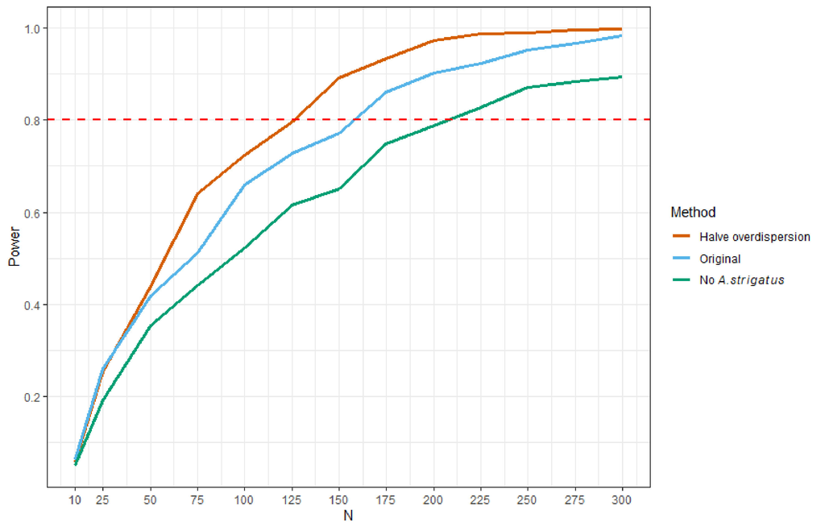

```r
powercurve_experiment_dat <- data.frame(sample_sizes = rep(sample_sizes, 3),
                                        Method = factor(rep(c("Original", "No abund", "Double theta"), each = 13),
                                                        levels = c("Double theta", "Original", "No abund")),
                                              Power = c(unlist(c(power_estimates, power_estimatesa, power_estimatesb))))


#plot power curve
ggplot(powercurve_experiment_dat, aes(x = sample_sizes, y = Power, colour = Method)) +
  geom_line(size = 1.1) + theme_bw() + geom_hline(yintercept = 0.8, linetype = "dashed", color = "red", size = 1) +
  xlab("N") + ylab("Power") + scale_x_continuous(breaks = sample_sizes) + theme(legend.text.align = 0) +
  scale_y_continuous(breaks = c(0.2, 0.4, 0.6, 0.8, 1.0)) +
  scale_colour_manual(
    values = c("#D55E00", "#56B4E9", "#009E73"),
    labels = c("Halve overdispersion", "Original", expression(paste("No " , italic(A.strigatus))))
  )
```

This demonstrates how sensitive our prior assumptions can be on resulting power, and in particular for abundant species.

For further details behind the methodology please go to [Maslen et al. 2023](https://doi.org/10.1111/2041-210X.14094), or for examples with more complicated effect size specifications go to the examples within ecopower.

If you use this package for sample size analysis in an associated paper or otherwise, please cite [Maslen et al. 2023](https://doi.org/10.1111/2041-210X.14094).

### References

Campbell, A. H., Marzinelli, E. M., Vergés, A., Coleman, M. A., & Steinberg, P. D. (2014). Towards restoration of missing underwater forests. PloS one, 9(1), e84106.

Coleman, M. A., Kelaher, B. P., Steinberg, P. D., & Millar, A. J. (2008). Absence of a large brown macroalga on urbanized rocky reefs around Sydney, Australia, and evidence for historical decline 1. Journal of phycology, 44(4), 897-901.

Marzinelli, E. M., Campbell, A. H., Vergés, A., Coleman, M. A., Kelaher, B. P., & Steinberg, P. D. (2014). Restoring seaweeds: does the declining fucoid Phyllospora comosa support different biodiversity than other habitats?. Journal of Applied Phycology, 26, 1089-1096.

Marzinelli, E. M., Leong, M. R., Campbell, A. H., Steinberg, P. D., & Vergés, A. (2016). Does restoration of a habitat‐forming seaweed restore associated faunal diversity?. Restoration Ecology, 24(1), 81-90.

Maslen, B., Popovic, G., Lim, M., Marzinelli, E., & Warton, D. (2023). How many sites? Methods to assist design decisions when collecting multivariate data in ecology. Methods in Ecology and Evolution, 14(6), 1564-1573.

Popovic, G. C., Hui, F. K., & Warton, D. I. (2018). A general algorithm for covariance modeling of discrete data. Journal of Multivariate Analysis, 165, 86-100.

Vergés, A., Campbell, A. H., Wood, G., Kajlich, L., Eger, A. M., Cruz, D., Langley, M., Bolton, D., Coleman, M.A., Turpin, J., et al. (2020). Operation Crayweed: Ecological and sociocultural aspects of restoring Sydney’s underwater forests. Ecological Management & Restoration, 21(2), 74-85.

Wood, G., Marzinelli, E. M., Coleman, M. A., Campbell, A. H., Santini, N. S., Kajlich, L., Verdura, J., Wodak, J., Steinberg, P.D., & Vergés, A. (2019). Restoring subtidal marine macrophytes in the Anthropocene: trajectories and future-proofing. Marine and Freshwater Research, 70(7), 936-951.